# Registro de Esclerosis Múltiple del Hospital Universitario Nacional de Colombia

## Investigadores

Simón Cárdenas Robledo

Claudia Guío

Liliana Duarte

Laura Estefanía Arenas Vargas

Sonia Patricia Carreño Moreno

Lorena López

## Introducción

El registro de Esclerosis Múltiple (EM) del Hospital Universitario Nacional de Colombia (REMHUN) se inició en el año 2020, tras cuatro años de atención de pacientes con EM. El REMHUN es un estudio observacional, de diseño retrospectivo y prospectivo, que incluye pacientes con EM confirmada, pacientes con un primer episodio desmielinizante que no satisfacen criterios de EM (síndrome clínico aislado - CIS) y pacientes con lesiones en resonancia magnética de apariencia desmielinizante encontradas como hallazgo incidental (síndrome radiológico aislado - RIS).

Este estudio fue aprobado por el [Comité de Ética en Investigación del HUN](https://www.hun.edu.co/comite-de-etica) el 4 de febrero del año 2020 (CEI-HUN-acta-2019-12)

## Enrolamiento

Nuestro registro cuenta con información clínica de visitas con determinación del puntaje EDSS, sobre recaídas, tratamientos modificadores de la EM (TMEs) y resonancias magnéticas.

Desde su primera visita en nuestro centro, los pacientes han tenido un seguimiento de 51.6 meses en promedio, para un acumulado de 2470.2 años/paciente.

Durante este tiempo se han hecho un total de 4623 determinaciones de EDSS, para un promedio de 8.1 determinaciones por paciente.

Contamos con información sobre 1298 recaídas y 5084 resonancias magnéticas, de las cuales 2303 son resonancias cerebrales.

## Datos demográficos

Los datos demográficos básicos de los pacientes incluídos se muestran a continuación:

### Sexo:

Como es usual en la Esclerosis Múltiple, en nuestro registro predominan las mujeres, con un 70% del total, para una relación mujer:hombre de 2.4:1.

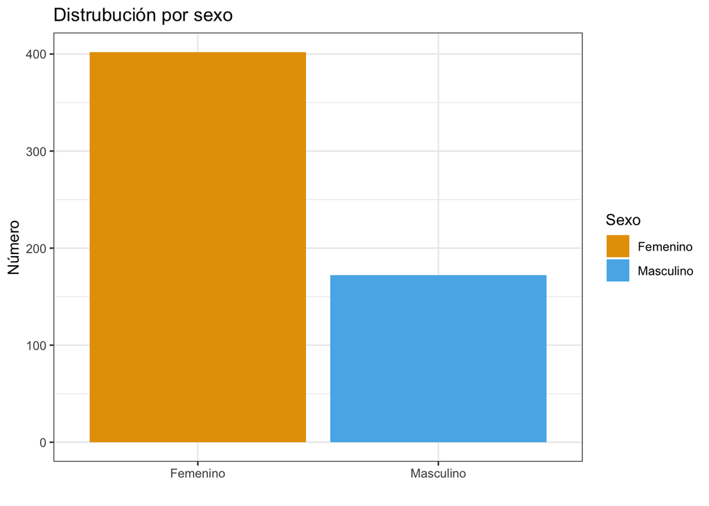

### Edad:

El grupo de pacientes reclutados tiene una edad promedio de 44.3 años, con una desviación estándar de 12 años. Las mujeres tienen una edad promedio de 44.8 y los hombres de 43.3 años. La distribución de edad de acuerdo al sexo se presenta a continuación:

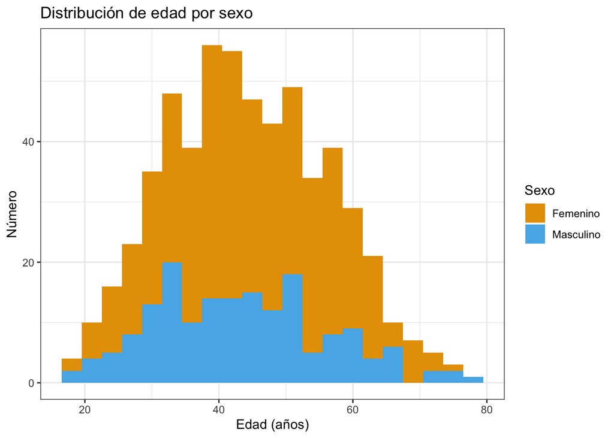

## Datos clínicos

A continuación, se presentan las características clínicas básicas de los pacientes.

### Edad y forma de inicio

La edad promedio (desviación estándar) de inicio de la enfermedad es de 32.2 (10.3) años. La mayoría de los pacientes (90.9%) han debutado con un curso en recaídas y remisiones, mientras que el resto lo han hecho en forma de EM primaria progresiva.

La edad de inicio difiere en los pacientes con un debut en forma de EM primaria progresiva (EMPP - 40.6 años) en comparación con quienes debutan en formas recurrentes de la EM (EMRR - 31.5 años), como se puede ver en la figura:

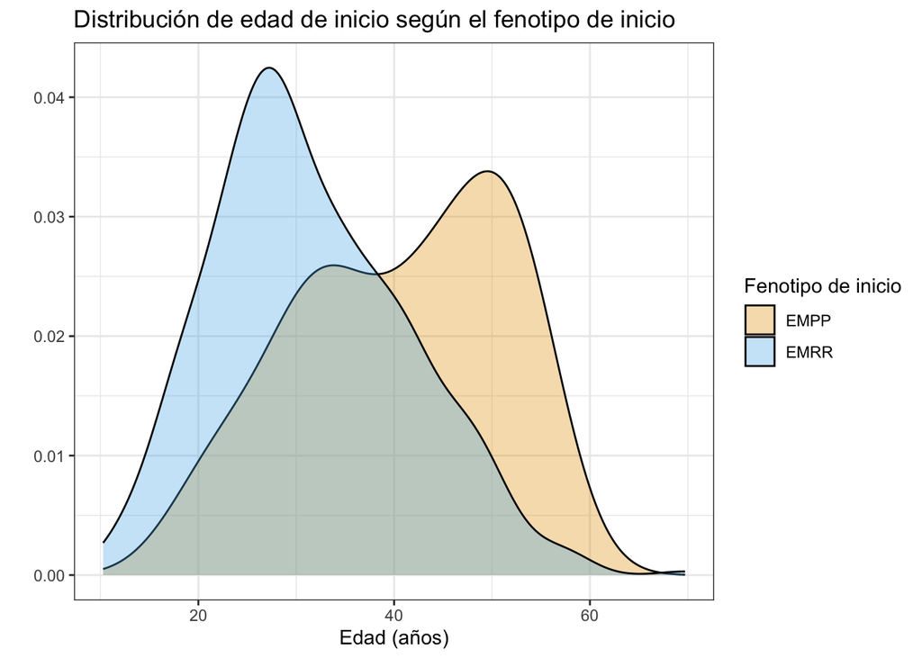

Las topografías del SNC en el momento del debut han sido supratentoriales en 43 (7.5%), de fosa posterior en 121 (21.1%), médula espinal en 272 (47.4%) y vías ópticas en 107 (18.6%).

La distribución de las topografías de inicio según el fenotipo de inicio se muestran a continuación:

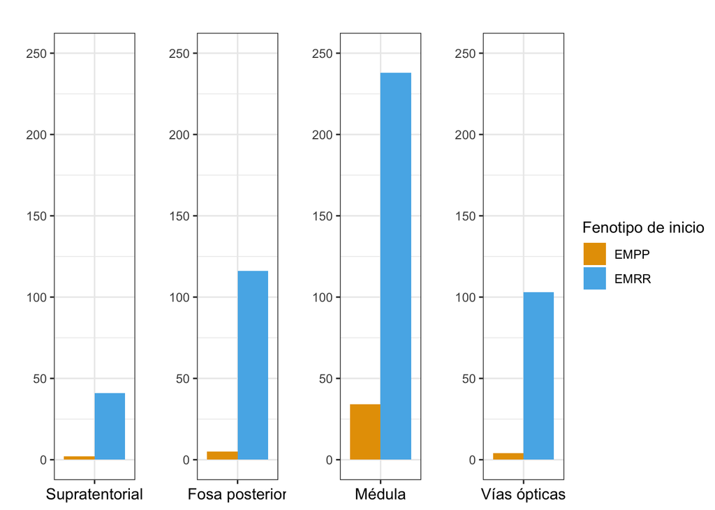

### Recaídas

Las recaídas son muy comunes en las manifestaciones de la EM. La mayoría de los pacientes en nuestro registro tiene una forma recurrente de la enfermedad. La tasa anual de recaídas (TAR) en general en la muestra de nuestro registro es 0.19 recaídas por paciente por año. Esto incluye tanto la información sobre las recaídas recabada de forma retrospectiva (TAR: 0.25), como de forma prospectiva desde que inició el seguimiento de cada paciente (TAR: 0.09).

### Tratamiento

De los 574 pacientes incluidos en el registro, 506 (88.15%) están bajo tratamiento actualmente.

La distribución de los tratamientos se presenta a continuación:

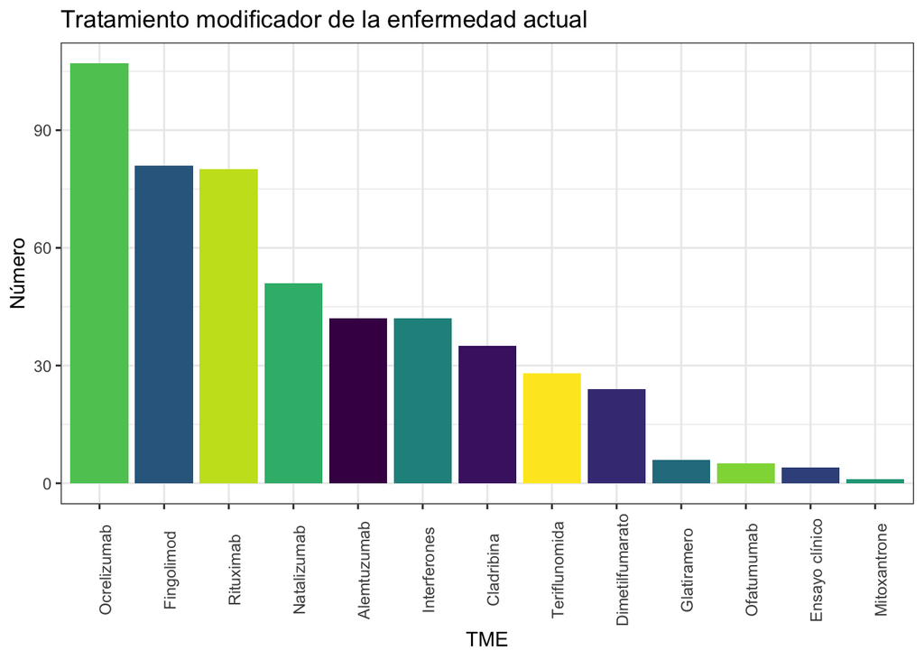

### Discapacidad

#### Estado actual de discapacidad

En el momento de la última evaluación, la mediana (rango intercuartílico) de EDSS era de 2.0 (1.0 - 3.5) puntos, con valores entre 0.0 y 9.5.0

La distribución de puntajes de EDSS se muestra a continuación.

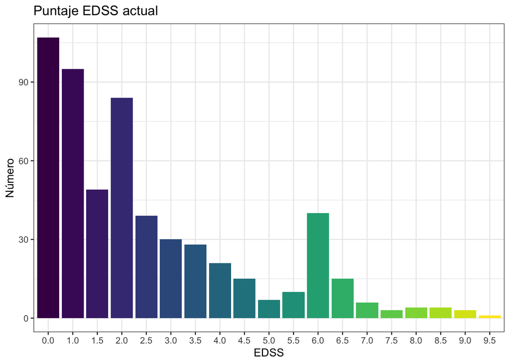

#### Discapacidad a lo largo del tiempo

El comportamiento de EDSS a lo largo del tiempo se muestra en la figura a continuación. En esta, cada línea corresponde a un paciente y cada punto a una determinación de EDSS. En el eje horizontal se muestran los meses transcurridos desde la primera visita al centro.

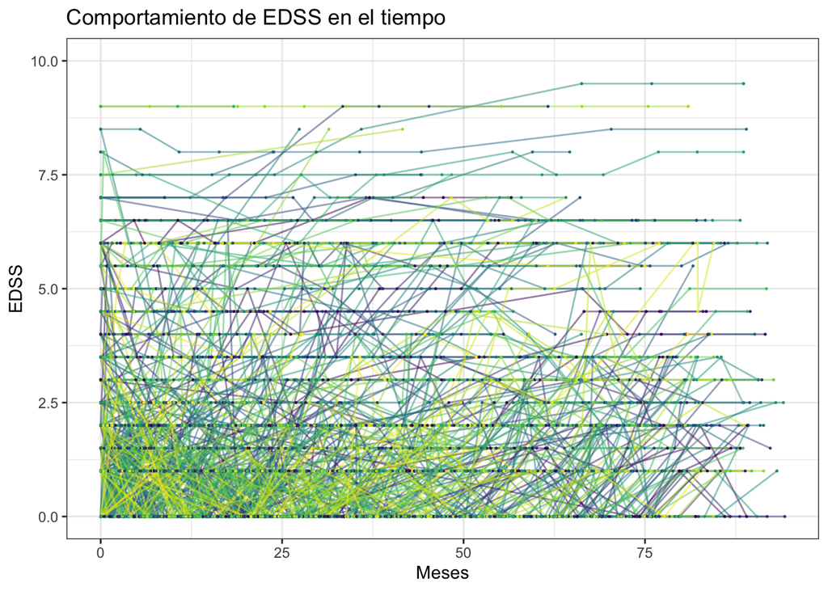

### Respuesta al tratamiento

A continuación se presentan los datos de recaídas y de discapacidad bajo los diferentes TME de forma individual. Únicamente se presentan los datos que han sido recolectados desde la primera visita en nuestro centro en adelante.

#### Interferones

##### Recaídas

65 pacientes han estado expuestos a interferones bajo el cuidado en nuestro centro, con una media (SD) de 22.3 (18.4) y un total de 1607 meses de observación de la exposición a este grupo de medicamentos. Durante este tiempo se observaron 13 recaídas, en 11 pacientes, para una TAR de 0.097.

##### Discapacidad

En los 65 pacientes observados bajo el tratamiento con interferones, se han hecho 288 determinaciones de EDSS.

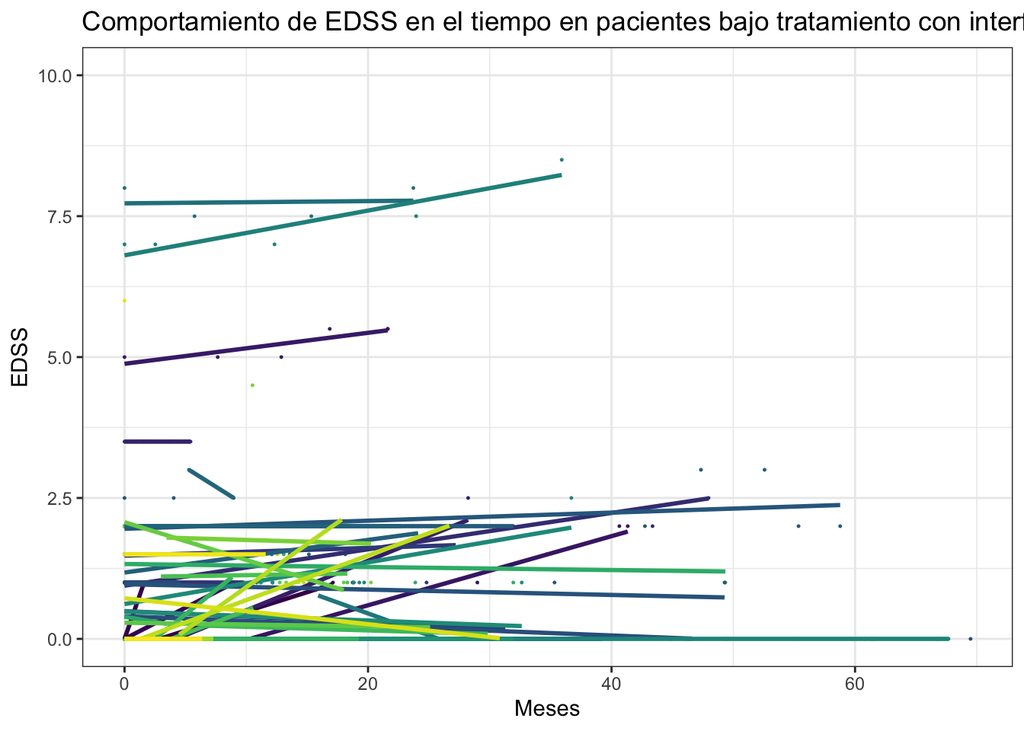

#### Glatiramero

##### Recaídas

14 pacientes han estado expuestos a glatiramero bajo el cuidado en nuestro centro, con una media (SD) de 24.4 (20.4) y un total de 341 meses de observación de la exposición a este medicamento. Durante este tiempo se observaron 2 recaídas, en 2 pacientes, para una TAR de 0.07.

##### Discapacidad

En los 14 pacientes observados bajo el tratamiento con glatiramero, se han hecho 53 determinaciones de EDSS.

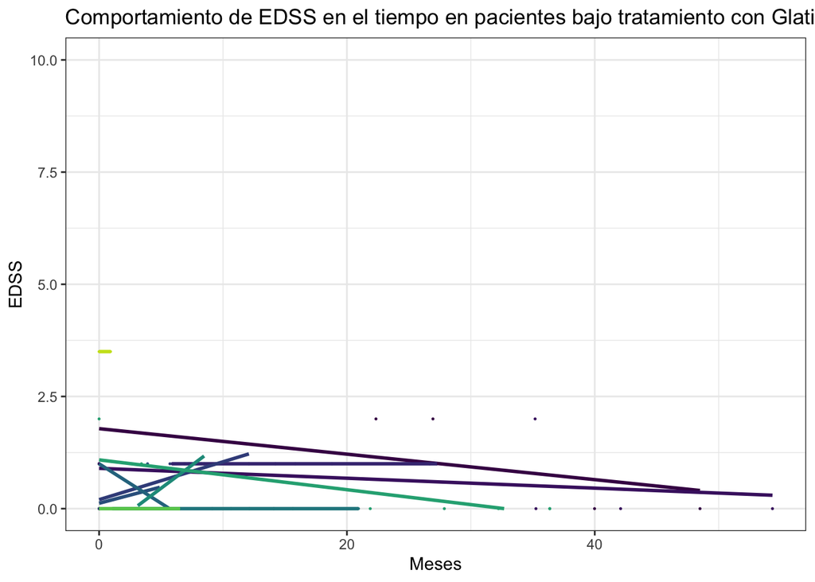

#### Teriflunomida

##### Recaídas

15 pacientes han estado expuestos a teriflunomida bajo el cuidado en nuestro centro, con una media (SD) de 28.2 (24) y un total de 423 meses de observación de la exposición a este medicamento. Durante este tiempo se observaron 2 recaídas, en 2 pacientes, para una TAR de 0.057.

##### Discapacidad

En los 15 pacientes observados bajo el tratamiento con teriflunomida, se han hecho 75 determinaciones de EDSS.

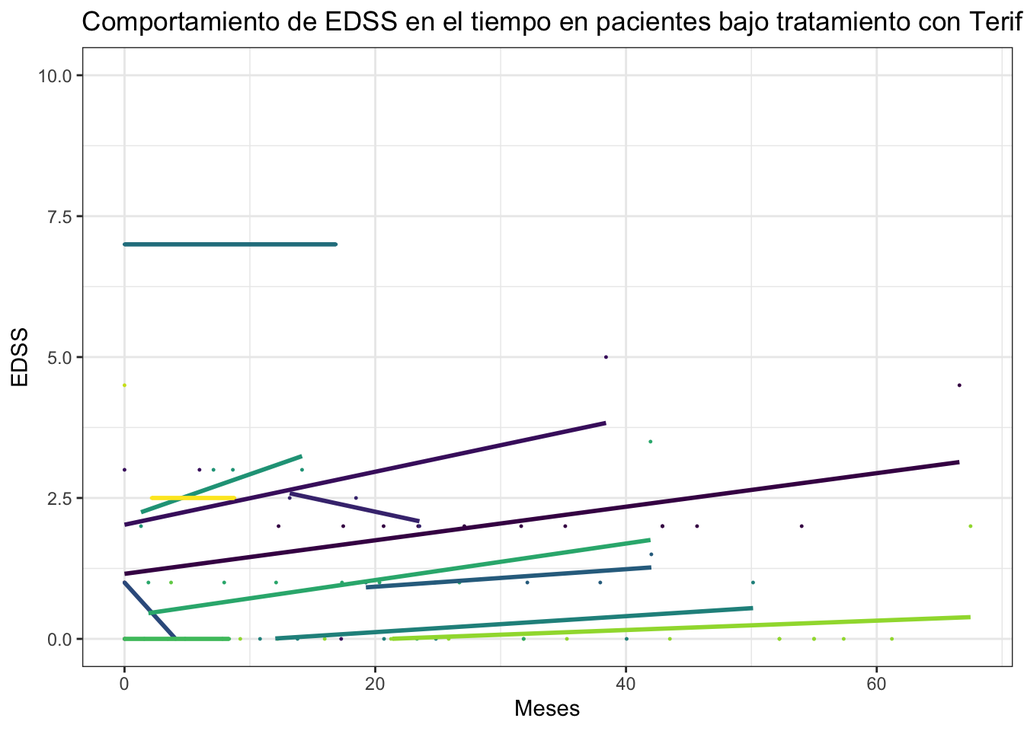

#### Dimetilfumarato

##### Recaídas

22 pacientes han estado expuestos a dimetilfumarato bajo el cuidado en nuestro centro, con una media (SD) de 25.2 (21.4) y un total de 555 meses de observación de la exposición a este medicamento. Durante este tiempo se observaron 10 recaídas, en 8 pacientes, para una TAR de 0.216.

##### Discapacidad

En los 22 pacientes observados bajo el tratamiento con dimetilfumarato, se han hecho 85 determinaciones de EDSS.

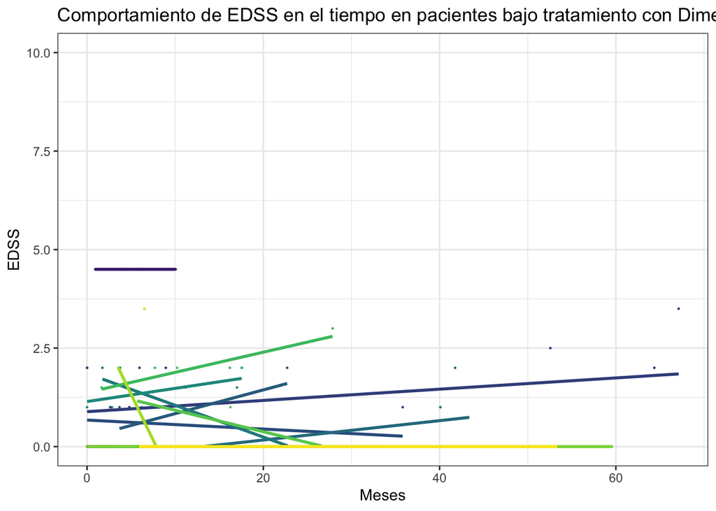

#### Fingolimod

##### Recaídas

64 pacientes han estado expuestos a fingolimod bajo el cuidado en nuestro centro, con una media (SD) de 24.9 (17) y un total de 1644 meses de observación de la exposición a este medicamento. Durante este tiempo se observaron 26 recaídas, en 21 pacientes, para una TAR de 0.19.

##### Discapacidad

En los 64 pacientes observados bajo el tratamiento con fingolimod, se han hecho 335 determinaciones de EDSS.

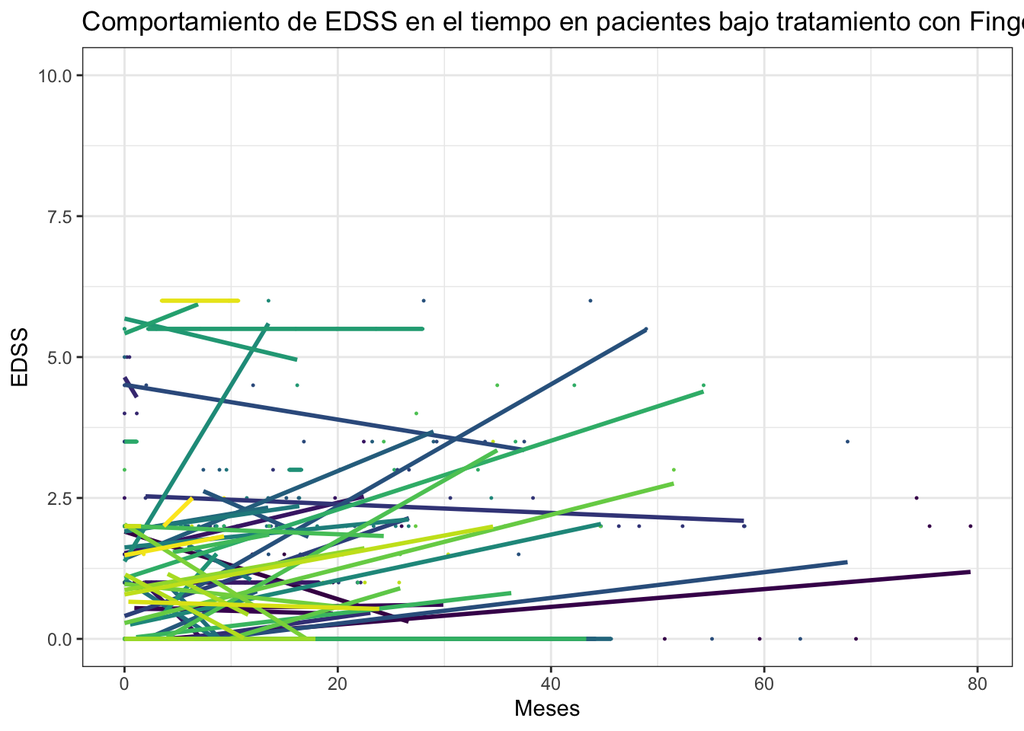

#### Cladribina

##### Recaídas

35 pacientes han estado expuestos a cladribina bajo el cuidado en nuestro centro, con una media (SD) de 19.4 (9.1) y un total de 1941 meses de observación de la exposición a este medicamento. Durante este tiempo se observaron 25 recaídas, en 5 pacientes, para una TAR de 0.155.

##### Discapacidad

En los 35 pacientes observados después del tratamiento con cladribina, se han hecho 249 determinaciones de EDSS.

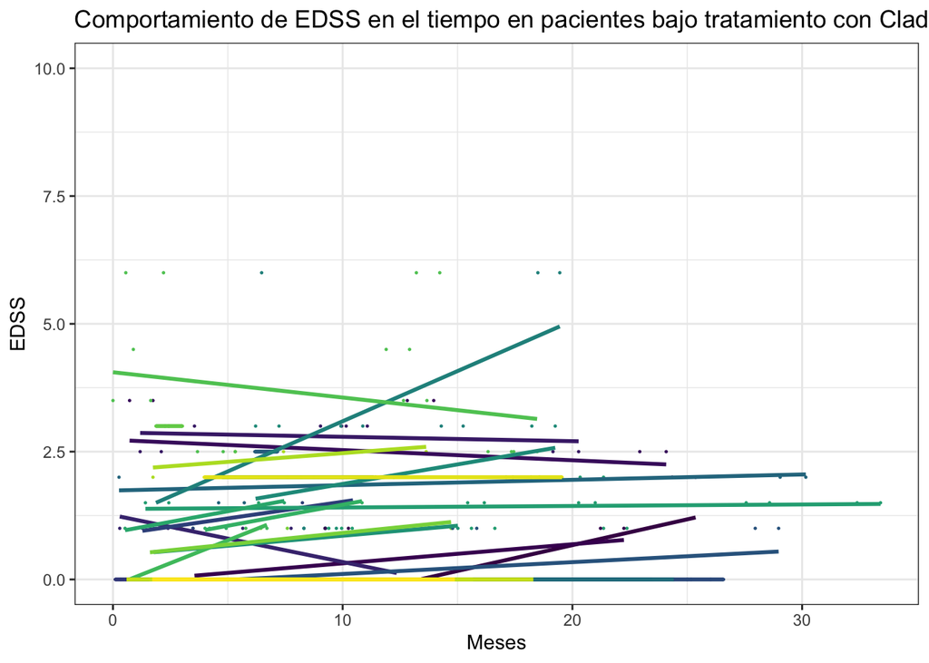

#### Natalizumab

##### Recaídas

60 pacientes han estado expuestos a natalizumab bajo el cuidado en nuestro centro, con una media (SD) de 26.8 (20.7) y un total de 1663 meses de observación de la exposición a este medicamento. Durante este tiempo se observaron 11 recaídas, en 10 pacientes, para una TAR de 0.079.

##### Discapacidad

En los 60 pacientes observados bajo el tratamiento con natalizumab, se han hecho 286 determinaciones de EDSS.

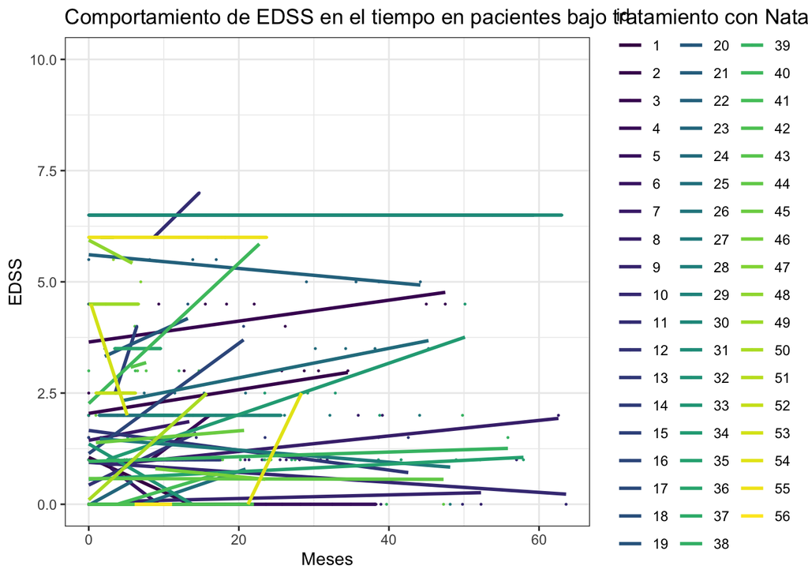

#### Alemtuzumab

##### Recaídas

48 pacientes han estado expuestos a alemtuzumab bajo el cuidado en nuestro centro, con una media (SD) de 40.9 (21.8) y un total de 3840 meses de observación de la exposición a este medicamento. Durante este tiempo se observaron 65 recaídas, en 22 pacientes, para una TAR de 0.203.

##### Discapacidad

En los 48 pacientes observados después del tratamiento con alemtuzumab, se han hecho 589 determinaciones de EDSS.

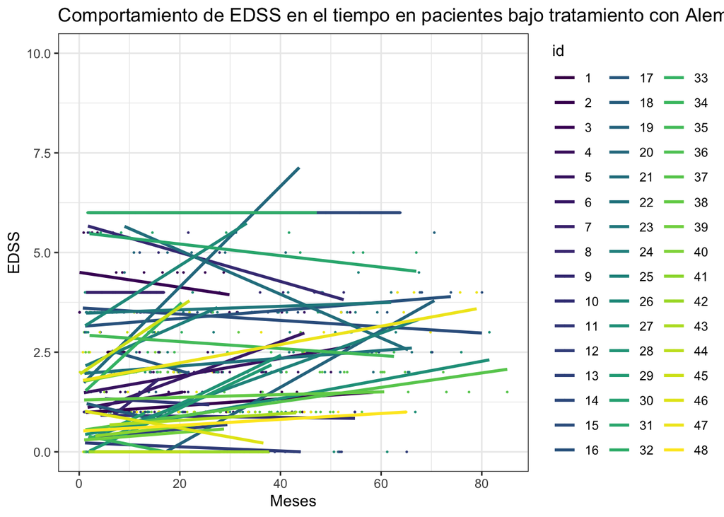

#### Rituximab

##### Recaídas

79 pacientes han estado expuestos a rituximab bajo el cuidado en nuestro centro, con una media (SD) de 16 (20.7) y un total de 1260 meses de observación de la exposición a este medicamento. Durante este tiempo se observaron 4 recaídas, en 3 pacientes, para una TAR de 0.038.

##### Discapacidad

En los 79 pacientes observados bajo el tratamiento con rituximab, se han hecho 197 determinaciones de EDSS.

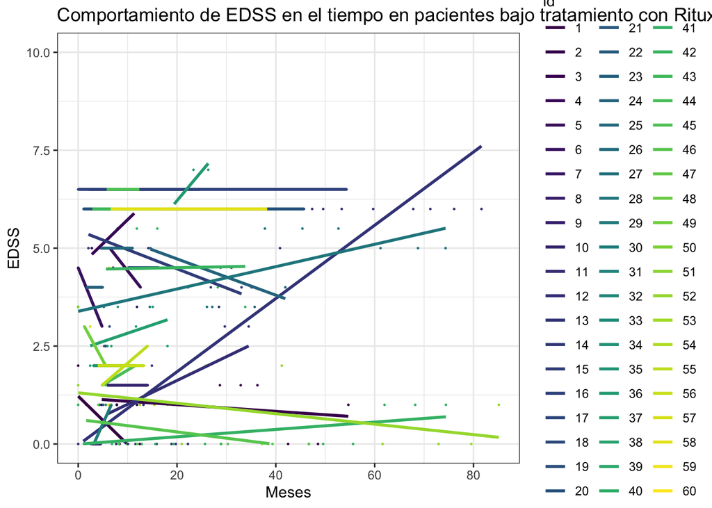

#### Ocrelizumab

##### Recaídas

108 pacientes han estado expuestos a ocrelizumab bajo el cuidado en nuestro centro, con una media (SD) de 20 (16.8) y un total de 2175 meses de observación de la exposición a este medicamento. Durante este tiempo se observaron 9 recaídas, en 7 pacientes, para una TAR de 0.05.

##### Discapacidad

En los 108 pacientes observados bajo el tratamiento con ocrelizumab, se han hecho 284 determinaciones de EDSS.

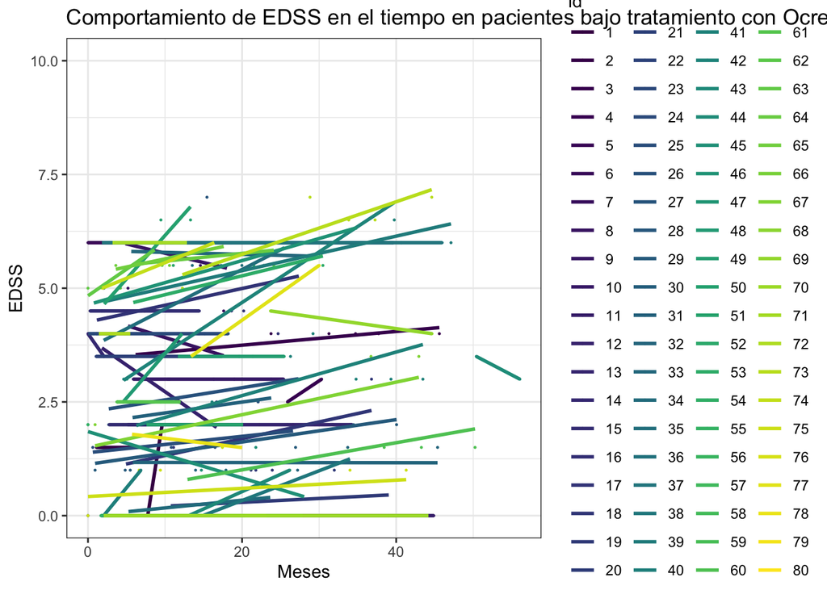

#### Ofatumumab

##### Discapacidad

En los 5 pacientes observados bajo el tratamiento con ofatumumab, se han hecho 0 determinaciones de EDSS.

[figure not shown]

## Colaboración

Los datos del REMHUN no son públicos. Sin embargo, el equipo de investigación está disponible para realizar proyectos de investigación colaborativos. Este registro [hace parte](https://msda.emif-catalogue.eu/login?ref=c/msda/fingerprint/d7a96ebb66a2cb4eeff9cbe6b8ecf532/) del catálogo de la [Multiple Sclerosis Data Alliance](https://www.msdataalliance.org/cat/16/MSDA%20Catalogue). En caso de tener interés en colaborar, por favor escribir al correo investigacion.em@hun.edu.co.

## Financiación

Este proyecto ha sido posible con el apoyo de

[figure not shown]

a través de su filial [BIIB-Colombia](https://www.biibcolombia.co/).